# Horizontal diphthong shift in New Zealand English (or some other title)

Supplementary materials: *Data processing

Márton Sóskuthy, Jen Hay & James Brand Corresponding author: Márton Sóskuthy Email: marton.soskuthy@ubc.ca

08 November, 2021

# Document outline

**Purpose: Introduce the data and libraries used**

This document provides the code used during the data processing stages of the Sóskuthy, Hay and Brand (2020) manuscript, submitted to JASA. It contains all the steps the authors carried out in order to produce the final data sets used in the analysis (see supplementary materials: Analysis file).

### Data decription

NOTE TO MARCI:

I have copied and pasted some of this from the co-variation paper. One thing we should talk about is anonymisation and data sharing. For the co-variation paper we removed a lot of data during the processing, the pre-processed data was not shared. I think given the size of the data here, we could share the raw data (following the same anonymisation steps, so speaker becomes something like MU_0001, word becomes word_00001, other variables not used in the analysis are removed).

I think the filtering steps work very well, so we do get a good balance between quantity and quality and they could be used by other researchers, so having both the raw and final data shows how much mess we get and how we address that mess.

I added the default process with Praat settings from LaBB-CAT, not sure if you used this or a custom script, so they might need to be changed.

### Libraries

First, we will load in the relevant R libraries required to run the processing procedures and then load in the data itself.

In order for the code in this document to work, the libraries are required to be installed and loaded into your R session. If you do not have any of the libraries installed, you can run `install.packages("LIBRARY NAME")` (change “LIBRARY NAME” to the required library name, e.g. `install.packages("tidyverse")`) which should resolve any warning messages you might get.

```r
#load in the libraries
library(tidyverse)
library(phonTools)
library(gganimate)
library(mgcv)
library(ggforce)
library(parallel)
library(emuR)
library(cowplot)
library(shiny)
library(soundgen)

#set a seed in case there are any stochastic processes
set.seed(3.14159)

#set start time
cat(paste0("Start time:\n", format(Sys.time(), "%d %B %Y, %r")))
start_time <- Sys.time()

#check information about R session, this will give details of the R setup on the authors computer at the time of running. If any of the outputs are not reproduced as in the html file produced from this markdown document (see repository), there may be differences in the package versions or setup on your computer. You can update packages by running utils::update.packages()
sessionInfo()
```

[output not shown]

### Data processing steps

As mentioned previously, we will be working with data for the NZE dipthongs PRICE and MOUTH. For each of the data sets we will:

The raw data can be found in the `raw_data` folder

The final data can be found in the `final_data` folder

# PRICE

**Step 1**

Data wrangling - this step takes the raw data and wrangles it into a more useable format

```r
# price_wide1 <- read_csv("../raw_data/price.csv", na = c("n/a", "", "NA"))
#
# saveRDS(price_wide1, "raw_data_JB/price.rds")

#load in the data
price_wide <- readRDS("raw_data_JB/price.rds")

# removing some non-essential columns, renaming columns
# positive select statement will help with generalisability to other data sets
price <- price_wide %>%
  #select which variables to keep
  dplyr::select(`Number`, `Speaker`, `Corpus`, `participant_gender`,
                `participant_year_of_birth`, `Before Match`, `Text`, `After Match`,
                `syllables/sec`, `Target phonemic transcription`, `Target lemma`, `Target words since last mention`,
                `Target last wordform instance same speaker (sec. ago)`, `Target frequency (celex lemma)`, `Target freq (celex wordform)`,
                `Target orthography`, `Match segments`, `Target segments`, `Target segments start`,
                `Target segments end`, matches("(time|F[1-3]|error).*")) %>%
  #reformat column names
  select_all(tolower) %>%
  select_all(function (x) {gsub("[ -]", "_", x)}) %>%
  select_all(function (x) {gsub("/", "_per_", x)}) %>%
  select_all(function (x) {gsub("[()]", "", x)}) %>%
  select_all(function (x) {gsub("_sec._ago", "", x)}) %>%
  select_all(function (x) {gsub("target_", "", x)}) %>%
  rename(sex=participant_gender,
         yob=participant_year_of_birth,
         phon=phonemic_transcription,
         celex_lemma=frequency_celex_lemma,
         celex_wf=freq_celex_wordform,
         wordform=orthography) %>%
  #create a vowel duration variable
  mutate(dur=segments_end - segments_start,
         speaker = as.character(speaker)) %>%
  #drop variables
  dplyr::select(-`segments_start`, -`segments_end`)

# now move to long format
price <- price %>%
  pivot_longer(cols = time_0.0:f3_time_1.0, names_to = "F_variable", values_to = "F_value") %>%
  #get measurement number (1:11) for F1, F2 and F3
  mutate(measurement_no = as.numeric(str_sub(F_variable, -3, -1)),
         F_variable = ifelse(str_sub(F_variable, 1, 2) == "ti", "time", str_sub(F_variable, 1, 2))) %>%
  pivot_wider(names_from = F_variable, values_from = F_value) %>%
  #create a token id for each individual token
  mutate(id = paste0(number, "_PRICE_", speaker),
         id_str=paste0("price_", id)) %>%
  arrange(id, measurement_no) %>%
  #get token counts for each speaker
  group_by(speaker) %>%
  mutate(speaker_n=n_distinct(id)) %>%
  ungroup() %>%
  mutate(generation = ifelse(yob %in% c(1857:1880), "1857-1880",
                             ifelse(yob %in% c(1881:1900), "1881-1900",
                                    ifelse(yob %in% c(1901:1920), "1901-1920",
                                           ifelse(yob %in% c(1921:1940), "1921-1940",
                                                  ifelse(yob %in% c(1941:1960), "1941-1960",
                                                         ifelse(yob %in% c(1961:1980), "1961-1980",
                                                                ifelse(yob %in% c(1980:1990), "1980+","xxx")))))))) %>%
  arrange(speaker, id, measurement_no)

#make a data frame to store the number of distinct tokens and rows at each filtering step
step = 1
price_n_tokens <- data.frame(step =  step,
                             description = as.character("full data no filtering"),
                             n_tokens = price %>% select(id) %>% distinct() %>% nrow(),
                             n_rows = price %>% nrow(),
                             n_speakers = price %>% select(speaker) %>% n_distinct(),
                             n_tokens_removed = 0,
                             n_rows_removed = 0,
                             n_speakers_removed = 0) %>%
  mutate(description = as.character(description))

price_n_tokens
```

| step | description | n_tokens | n_rows | n_speakers | n_tokens_removed | n_rows_removed | n_speakers_removed |
| --- | --- | --- | --- | --- | --- | --- | --- |
| 1 | full data no filtering | 68726 | 755986 | 586 | 0 | 0 | 0 |

```r
#make a plot showing all the trajectories for each speaker
speakers <- unique(price$speaker)

pdf("speaker_plots/checking_price_raw.pdf", onefile=T, width=7.3, height=10)
  for (i in seq(1,length(speakers),70)) {
    small <- filter(price, speaker %in% speakers[i:min(i+69,length(speakers))])
    p <- ggplot(small, aes(x=measurement_no, y=f1, group=id)) +
      geom_line(col="red", alpha=0.2) +
      geom_line(aes(y=f2), col="blue", alpha=0.2) +
      scale_x_continuous(breaks = c(0.25, 0.50, 0.75), labels = c("25%", "50%", "75%")) +
      scale_y_continuous(breaks = c(0, 1000, 2000, 3000), limits = c(0, 3680)) +
      facet_wrap(~speaker, nrow=10, ncol=7) +
      theme_bw() +
      theme(legend.position = "none",
              axis.text.x = element_text(angle = 45, hjust = 1))
    print(p)
  }
  dev.off()
```

```r
#make a function to update this information at each filtering step
update_n_tokens_price <- function(step, data, description){

  price_n_tokens <<- rbind(price_n_tokens,tibble(step =  step,
           description = description,
           n_tokens = data %>% select(id) %>% distinct() %>% nrow(),
           n_rows = data %>% nrow(),
           n_speakers = data %>% select(speaker) %>% n_distinct(),
           n_tokens_removed = price_n_tokens[step - 1, "n_tokens"] - data %>% select(id) %>% distinct() %>% nrow(),
           n_rows_removed = price_n_tokens[step - 1, "n_rows"] - data %>% nrow(),
           n_speakers_removed =  price_n_tokens[step - 1, "n_speakers"] - data %>% select(speaker) %>% n_distinct()
           ) %>%
             as.data.frame()
)
}
```

**Step 2**

Filter out tokens with too much missing data/Praat processing errors

```r
#filter out NAs
price2 <- price %>%
  group_by(id) %>%
  # also filtering entire vowels with too many NA's
  filter(!(sum(is.na(time)) > 4 | sum(is.na(f1)) > 4 | sum(is.na(f2)) > 4)) %>%
  ungroup() %>%
  #get token counts
  group_by(speaker) %>%
  mutate(speaker_n=n_distinct(id)) %>%
  ungroup()

price_removed_step2 <- anti_join(price %>% select(-speaker_n), price2 %>% select(-speaker_n))

update_n_tokens_price(step = 2, price2, "remove NA tokens")

price_n_tokens
```

| step | description | n_tokens | n_rows | n_speakers | n_tokens_removed | n_rows_removed | n_speakers_removed |
| --- | --- | --- | --- | --- | --- | --- | --- |
| 1 | full data no filtering | 68726 | 755986 | 586 | 0 | 0 | 0 |
| 2 | remove NA tokens | 64241 | 706651 | 575 | 4485 | 49335 | 11 |

**Step 3**

NOTE TO MARCI:

This list had a bit of a problem with reading the “−” character, as the data contains speaker names with a “-” (for some reason these are read in differently, even though they look the same), I have modified the list below so the speaker names have the “-”. I had a look at the final_data for PRICE and the speakers with a “-” were in that version, so from here on in the data may look slightly different.

Speaker exclusion:

In step 1, we created a pdf file with all the trajectories for each of the speakers. As the data was not hand-coded there are likely some data points that we want to remove. This step does have some subjectivity to it.

Based on the following criteria: exclude if…

- massive variation in f2 with no observable trend similar to individuals from same period
- consistent formant switching errors (f2 -> f1)
- very few tokens

All of this is based on the pdf from PRICE (the assumption being that formant tracking errors result from poor recording quality / idiosyncracies of a given speaker, and should therefore be similar across all vowels)

The list of speakers below are the ones identified as being questionable. These were checked by multiple authors and were agreed to be sufficiently poor quality to remove the speaker from the data.

We also remove instances of the word “like” (function words were otherwise filtered at the data extraction stage).

```r
# speaker exclusion list
exclude_speakers <- c("Ada Aitcheson", "Anna Hayes", "Annie Hamilton", "Catherine King", "Christina Bisset", "Edith German", "Henry Swarbrick", "Hannah Cross", "Jessie Drinnan", "Jane Reid", "Marguerite Symons", "Annette Golding", "Elizabeth Arnott", "Jean Atkinson", "John Barron", "Ken Algie", "Mavis Jackson", "Nan Hay", "Sydney Farrell", "Rupert Pyle", "Ruth Greer", "Vera Hayward", "fyp09-6", "mon09-3", "mon97-19a", "mon96-2a", "mon99-1b", "mon99-13b", "mop02-5", "mop98-18", "myn97-6a", "myn97-9", "myp00-18a", "myp00-18a", "myp00-18a", "myp07-1a", "myp07-6", "myp94-17", "myp09-2", "myp94-8c", "myp98-12b","Betty Roberts","David Moore","Elizabeth Arnott","fon94-3","fop01-13","fop02-9","fop95-27","fyn94-12a","fyn94-26c","George Rivers","Joan Wicks","Kathleen Fountain","Lillian Aitken","Margaret Annan","Myra Ralston","Pat Toomey")

price3 <- price2 %>%
  filter(!(speaker %in% exclude_speakers),
         wordform!="like"
         )

update_n_tokens_price(step = 3, price3, "remove speakers with poor quality data")

price_n_tokens
```

| step | description | n_tokens | n_rows | n_speakers | n_tokens_removed | n_rows_removed | n_speakers_removed |
| --- | --- | --- | --- | --- | --- | --- | --- |
| 1 | full data no filtering | 68726 | 755986 | 586 | 0 | 0 | 0 |
| 2 | remove NA tokens | 64241 | 706651 | 575 | 4485 | 49335 | 11 |
| 3 | remove speakers with poor quality data | 49275 | 542025 | 522 | 14966 | 164626 | 53 |

```r
price_removed_step3 <- anti_join(price2 %>% select(-speaker_n), price3 %>% select(-speaker_n))
```

**Step 4**

Remove tokens with hesitations or where the transcription looks questionable (a few spot checks suggest that this is overlapping speech and picking up on the wrong word).

We will also remove tokens that have a very short duration (< 0.03ms) and tokens that are from a word-list.

NOTE TO MARCI:

I added in the duration and word list steps here, tokens with NA values were from word lists so presumably should be removed?

```r
price4 <- price3 %>%
  filter(!grepl("~", wordform),
         grepl("2", phon),
         round(dur, 3) >= 0.03,
         !is.na(syllables_per_sec))

update_n_tokens_price(step = 4, price4, "labb-cat issues")

price_removed_step4 <- anti_join(price3 %>% select(-speaker_n), price4 %>% select(-speaker_n))

price_n_tokens
```

| step | description | n_tokens | n_rows | n_speakers | n_tokens_removed | n_rows_removed | n_speakers_removed |
| --- | --- | --- | --- | --- | --- | --- | --- |
| 1 | full data no filtering | 68726 | 755986 | 586 | 0 | 0 | 0 |
| 2 | remove NA tokens | 64241 | 706651 | 575 | 4485 | 49335 | 11 |
| 3 | remove speakers with poor quality data | 49275 | 542025 | 522 | 14966 | 164626 | 53 |
| 4 | labb-cat issues | 43217 | 475387 | 503 | 6058 | 66638 | 19 |

**Step 4a**

Code for previous/following contexts based on voicing. No filtering here.

```r
# environments

# function to find segments in wordform by specifying position relative to
# target segment; 0=segment location, -1=preceding, +1=following
find_context <- function (text, segment, where) {
  locations <- as.vector(regexpr(segment, text))
  lengths <- nchar(text)
  context_locations <- locations + where
  contexts <- str_sub(text, context_locations, context_locations)
  contexts[context_locations <= 0] <- "none"
  contexts[context_locations > lengths] <- "none"
  return(contexts)
}

# add predictor coding for following voicing
price4 <- price4 %>%
  mutate(previous=find_context(phon, "2", -1),
         following=find_context(phon, "2", 1),
         following_voiceless=following %in% c("p","t","k","J","f","T","s","S","h"))
```

**Step 5**

Fixing trajectories!

We know that certain values are just unreasonable for f1 / f2 (depending on male / female), as a baseline let’s use American English vowel data (`h95`, Hillenbrand et al. (1995)) to estimate reasonable / unreasonable f1 / f2 (from `phonTools` package, run `?h95` for more information)

We are taking the upper (1%) and lower (99%) quantiles for female/male speakers in the h95 data for f1 and f2. Any values in our data that fall outside those values are removed.

We also calculate for each speaker, at each measurement point:

```
- the lower quartile (25%)

- the upper quartile (75%)

- the interquartile range
```

We then remove values that are either smaller than the lower quartile - (1.5 * inter-quartile range) or larger than the upper quartile + (1.5 * inter-quartile range)

```r
data(h95)

f_ranges <- h95 %>%
  group_by(type) %>%
  summarize(f1_lower=quantile(f1, 0.01),
            f1_upper=quantile(f1, 0.99),
            f2_lower=quantile(f2, 0.01),
            f2_upper=quantile(f2, 0.99)) %>%
  ungroup() %>%
  mutate(sex=recode(type, m="M", w="F")) %>%
  dplyr::select(-type)

not_outlier <- function (x) {
  x > (quantile(x, 0.25) - 1.5*IQR(x)) & x < (quantile(x, 0.75) + 1.5*IQR(x))
}

price5 <- price4 %>%
  # filtering based on reasonable ranges / sex
  inner_join(f_ranges, by="sex") %>%
  filter(!is.na(f1) & !is.na(f2)) %>%
  # marking clear f1/f2 outliers for each speaker as NAs
  group_by(speaker, measurement_no) %>%
  mutate(f1=ifelse(f1 > f1_lower & f1 < f1_upper & not_outlier(f1), f1, NA),
         f2=ifelse(f2 > f2_lower & f2 < f2_upper & not_outlier(f2), f2, NA)) %>%
  ungroup() %>%
  group_by(id) %>%
  # once again, removing trajectories with too many NAs
  filter(sum(is.na(f1)) < 5 & sum(is.na(f2)) < 5) %>%
  # filter(n(f1) < 7 & n(f2) < 5) %>%
  ungroup() %>%
  filter(!is.na(yob), !is.na(f1), !is.na(f2)) %>%
  select(-number, -id_str)

update_n_tokens_price(step = 5, price5, "trajectory fixing")

price_n_tokens
```

| step | description | n_tokens | n_rows | n_speakers | n_tokens_removed | n_rows_removed | n_speakers_removed |
| --- | --- | --- | --- | --- | --- | --- | --- |
| 1 | full data no filtering | 68726 | 755986 | 586 | 0 | 0 | 0 |
| 2 | remove NA tokens | 64241 | 706651 | 575 | 4485 | 49335 | 11 |
| 3 | remove speakers with poor quality data | 49275 | 542025 | 522 | 14966 | 164626 | 53 |
| 4 | labb-cat issues | 43217 | 475387 | 503 | 6058 | 66638 | 19 |
| 5 | trajectory fixing | 39110 | 399802 | 493 | 4107 | 75585 | 10 |

```r
price_removed_step5 <- anti_join(price4 %>% select(-speaker_n), price5 %>% select(-speaker_n))
```

**Step 6**

NOTE TO MARCI:

I added in this step here. It looked like some tokens had big fluctuations in their trajectories (mainly for f2). This tries to filter out measurement points that change dramatically. The increase/decrease values are arbitrary and there could be a more speaker intrinsic way to get this (I had a look at the standard deviations), but it does alright.

Additional filtering of questionnable trajectory points. This is based on:

```r
price6 <- price5 %>%
  # left_join(., price5 %>%
  #             group_by(id) %>%
  #             summarise(mean_f1 = mean(f1),
  #                       sd_f1 = sd(f1),
  #                       mean_f2 = mean(f2),
  #                       sd_f2 = sd(f2),
  #                       range_f1 = max(f1) - min(f1),
  #                       range_f2 = max(f2) - min(f2)) %>%
  #             ungroup()) %>%
  group_by(id) %>%
  mutate(f1_diff_plus1 = ifelse(is.na(abs(lag(f1) - f1)), 0, abs(lag(f1) - f1)),
         f2_diff_plus1 = ifelse(is.na(abs(lag(f2) - f2)), 0, abs(lag(f2) - f2)),
         f1_diff_minus1 = ifelse(is.na(abs(lead(f1) - f1)), 0, abs(lead(f1) - f1)),
         f2_diff_minus1 = ifelse(is.na(abs(lead(f2) - f2)), 0, abs(lead(f2) - f2))) %>%
  ungroup() %>%
  mutate(outlierF1 =
           ifelse(measurement_no == 1 & f1_diff_minus1 > 300, 1,
                  ifelse(measurement_no == 11 & f1_diff_plus1 > 300, 1,
                         ifelse(f1_diff_plus1 > 400 & f1_diff_minus1 > 400, 1,
                                ifelse(f1_diff_plus1 > 400, 1,
                                       ifelse(f1_diff_minus1 > 400, 1, 0))))),
         outlierF2 =
           ifelse(measurement_no == 1 & f2_diff_minus1 > 500, 1,
                  ifelse(measurement_no == 11 & f2_diff_plus1 > 500, 1,
                         ifelse(f2_diff_plus1 > 700 & f2_diff_minus1 > 700, 1,
                                ifelse(f2_diff_plus1 > 700, 1,
                                       ifelse(f2_diff_minus1 > 700, 1, 0)))))
    ) %>%
  # group_by(id) %>%
  # mutate(outlier2 = sum(outlier1, na.rm = TRUE))%>%
  filter(!outlierF1 > 0,
         !outlierF2 > 0) %>%
  group_by(speaker, id) %>%
  mutate(n_measurements = length(id)) %>%
  ungroup() %>%
  filter(n_measurements > 7)

update_n_tokens_price(step = 6, price6, "additional trajectory fixing")

price_n_tokens
```

| step | description | n_tokens | n_rows | n_speakers | n_tokens_removed | n_rows_removed | n_speakers_removed |
| --- | --- | --- | --- | --- | --- | --- | --- |
| 1 | full data no filtering | 68726 | 755986 | 586 | 0 | 0 | 0 |
| 2 | remove NA tokens | 64241 | 706651 | 575 | 4485 | 49335 | 11 |
| 3 | remove speakers with poor quality data | 49275 | 542025 | 522 | 14966 | 164626 | 53 |
| 4 | labb-cat issues | 43217 | 475387 | 503 | 6058 | 66638 | 19 |
| 5 | trajectory fixing | 39110 | 399802 | 493 | 4107 | 75585 | 10 |
| 6 | additional trajectory fixing | 36484 | 377829 | 493 | 2626 | 21973 | 0 |

```r
price_removed_step6 <- anti_join(price5 %>% select(-speaker_n), price6 %>% select(-speaker_n))
```

**create plots of all trajectories by speaker**

This plot can be compared to the raw data plot to see how the processing has removed outliers and speakers

```r
  # pdf("checking_price_unfiltered.pdf", onefile=T, width=7.3, height=10)
  # speakers <- unique(price$speaker)
  # for (i in seq(1,length(speakers),70)) {
  #   small <- filter(price, speaker %in% speakers[i:min(i+69,length(speakers))])
  #   p<- ggplot(small, aes(x=measurement_no, y=f1, group=id)) +
  #     facet_wrap(~speaker, nrow=10, ncol=7) +
  #     geom_line(col="red", alpha=0.5) +
  #     geom_line(aes(y=f2), col="blue", alpha=0.2)
  #   print(p)
  # }
  # dev.off()

  pdf("speaker_plots/checking_price_final.pdf", onefile=T, width=7.3, height=10)
  for (i in seq(1,length(speakers),70)) {
    small <- filter(price, speaker %in% speakers[i:min(i+69,length(speakers))])
    small1 <- filter(price6, speaker %in% speakers[i:min(i+69,length(speakers))])
    p <- ggplot(small, aes(x=measurement_no, y=f1, group=id)) +
      geom_line(data = small1, col="red", alpha=0.2) +
      geom_line(data = small1, aes(y=f2), col="blue", alpha=0.2) +
      scale_x_continuous(breaks = c(0.25, 0.50, 0.75), labels = c("25%", "50%", "75%")) +
      scale_y_continuous(breaks = c(0, 1000, 2000, 3000), limits = c(0, 3680)) +
      facet_wrap(~speaker, nrow=10, ncol=7) +
      theme_bw() +
      theme(legend.position = "none",
              axis.text.x = element_text(angle = 45, hjust = 1))
    print(p)
  }
  dev.off()
```

**save the data**

We will save the data as well as calculate the average F1, F2 and F3 (converted to barks) for each speaker and measurement point based on whether the vowel context is following a voiced or voiceless sound.

```r
# # save as RDS
# saveRDS(price_filtered, "../final_data/price_full_jasa.rds")
#
# price_filtered1 <- readRDS("~/Documents/GitHub/nz_vowels/final_data/price_full_jasa.rds")

saveRDS(price6, "final_data/price_full_jasa.rds")

# creating averaged data (male AND female)
price_filtered_avgs <- price6 %>%
  group_by(speaker, yob, sex, following_voiceless, measurement_no) %>%
  summarise(f1_avg=mean(bark(f1)),
            f2_avg=mean(bark(f2)),
            f3_avg=mean(bark(f3)),
            dur_avg=mean(dur)) %>%
  ungroup() %>%
  # for GAMMs again...
  mutate(AR_start=measurement_no==1)

# save as RDS
saveRDS(price_filtered_avgs, "final_data/price_averaged_jasa.rds")
```

# MOUTH

**Step 1**

Data wrangling - this step takes the raw data and wrangles it into a more useable format

```r
# mouth_wide1 <- read_csv("../raw_data/mouth.csv", na = c("n/a", "", "NA"))
#
# saveRDS(mouth_wide1, "raw_data_JB/mouth.rds")

#load in the data
mouth_wide <- readRDS("raw_data_JB/mouth.rds")

# removing some non-essential columns, renaming columns
# positive select statement will help with generalisability to other data sets
mouth <- mouth_wide %>%
  #select which variables to keep
  dplyr::select(`Number`, `Speaker`, `Corpus`, `participant_gender`,
                `participant_year_of_birth`, `Before Match`, `Text`, `After Match`,
                `syllables/sec`, `Target phonemic transcription`, `Target lemma`, `Target words since last mention`,
                `Target last wordform instance same speaker (sec. ago)`, `Target frequency (celex lemma)`, `Target freq (celex wordform)`,
                `Target orthography`, `Match segments`, `Target segments`, `Target segments start`,
                `Target segments end`, matches("(time|F[1-3]|error).*")) %>%
  #reformat column names
  select_all(tolower) %>%
  select_all(function (x) {gsub("[ -]", "_", x)}) %>%
  select_all(function (x) {gsub("/", "_per_", x)}) %>%
  select_all(function (x) {gsub("[()]", "", x)}) %>%
  select_all(function (x) {gsub("_sec._ago", "", x)}) %>%
  select_all(function (x) {gsub("target_", "", x)}) %>%
  rename(sex=participant_gender,
         yob=participant_year_of_birth,
         phon=phonemic_transcription,
         celex_lemma=frequency_celex_lemma,
         celex_wf=freq_celex_wordform,
         wordform=orthography) %>%
  #create a vowel duration variable
  mutate(dur=segments_end - segments_start,
         speaker = as.character(speaker)) %>%
  #drop variables
  dplyr::select(-`segments_start`, -`segments_end`)

# now move to long format
mouth <- mouth %>%
  pivot_longer(cols = time_0.0:f3_time_1.0, names_to = "F_variable", values_to = "F_value") %>%
  #get measurement number (1:11) for F1, F2 and F3
  mutate(measurement_no = as.numeric(str_sub(F_variable, -3, -1)),
         F_variable = ifelse(str_sub(F_variable, 1, 2) == "ti", "time", str_sub(F_variable, 1, 2))) %>%
  pivot_wider(names_from = F_variable, values_from = F_value) %>%
  #create a token id for each individual token
  mutate(id = paste0(number, "_MOUTH_", speaker),
         id_str=paste0("mouth_", id)) %>%
  arrange(id, measurement_no) %>%
  #get token counts for each speaker
  group_by(speaker) %>%
  mutate(speaker_n=n_distinct(id)) %>%
  ungroup() %>%
  mutate(generation = ifelse(yob %in% c(1857:1880), "1857-1880",
                             ifelse(yob %in% c(1881:1900), "1881-1900",
                                    ifelse(yob %in% c(1901:1920), "1901-1920",
                                           ifelse(yob %in% c(1921:1940), "1921-1940",
                                                  ifelse(yob %in% c(1941:1960), "1941-1960",
                                                         ifelse(yob %in% c(1961:1980), "1961-1980",
                                                                ifelse(yob %in% c(1980:1990), "1980+","xxx")))))))) %>%
  arrange(speaker, id, measurement_no)

#make a data frame to store the number of distinct tokens and rows at each filtering step
step = 1
mouth_n_tokens <- data.frame(step =  step,
                             description = as.character("full data no filtering"),
                             n_tokens = mouth %>% select(id) %>% distinct() %>% nrow(),
                             n_rows = mouth %>% nrow(),
                             n_speakers = mouth %>% select(speaker) %>% n_distinct(),
                             n_tokens_removed = 0,
                             n_rows_removed = 0,
                             n_speakers_removed = 0) %>%
  mutate(description = as.character(description))

mouth_n_tokens
```

| step | description | n_tokens | n_rows | n_speakers | n_tokens_removed | n_rows_removed | n_speakers_removed |
| --- | --- | --- | --- | --- | --- | --- | --- |
| 1 | full data no filtering | 43380 | 477180 | 586 | 0 | 0 | 0 |

```r
speakers_mouth <- unique(mouth$speaker)

#make a plot showing all the trajectories for each speaker
pdf("speaker_plots/checking_mouth_raw.pdf", onefile=T, width=7.3, height=10)
  for (i in seq(1,length(speakers_mouth),70)) {
    small <- filter(mouth, speaker %in% speakers_mouth[i:min(i+69,length(speakers_mouth))])
    p <- ggplot(small, aes(x=measurement_no, y=f1, group=id)) +
      geom_line(col="red", alpha=0.2) +
      geom_line(aes(y=f2), col="blue", alpha=0.2) +
      scale_x_continuous(breaks = c(0.25, 0.50, 0.75), labels = c("25%", "50%", "75%")) +
      scale_y_continuous(breaks = c(0, 1000, 2000, 3000), limits = c(0, 3680)) +
      facet_wrap(~speaker, nrow=10, ncol=7) +
      theme_bw() +
      theme(legend.position = "none",
              axis.text.x = element_text(angle = 45, hjust = 1))
    print(p)
  }
  dev.off()
```

```r
#make a function to update this information at each filtering step
update_n_tokens_mouth <- function(step, data, description){

  mouth_n_tokens <<- rbind(mouth_n_tokens,tibble(step =  step,
           description = description,
           n_tokens = data %>% select(id) %>% distinct() %>% nrow(),
           n_rows = data %>% nrow(),
           n_speakers = data %>% select(speaker) %>% n_distinct(),
           n_tokens_removed = mouth_n_tokens[step - 1, "n_tokens"] - data %>% select(id) %>% distinct() %>% nrow(),
           n_rows_removed = mouth_n_tokens[step - 1, "n_rows"] - data %>% nrow(),
           n_speakers_removed =  mouth_n_tokens[step - 1, "n_speakers"] - data %>% select(speaker) %>% n_distinct()
           ) %>%
             as.data.frame()
)
}
```

**Step 2**

Filter out tokens with too much missing data/Praat processing errors

```r
#filter out NAs
mouth2 <- mouth %>%
  group_by(id) %>%
  # also filtering entire vowels with too many NA's
  filter(!(sum(is.na(time)) > 4 | sum(is.na(f1)) > 4 | sum(is.na(f2)) > 4)) %>%
  ungroup() %>%
  #get token counts
  group_by(speaker) %>%
  mutate(speaker_n=n_distinct(id)) %>%
  ungroup()

mouth_removed_step2 <- anti_join(mouth %>% select(-speaker_n), mouth2 %>% select(-speaker_n))

update_n_tokens_mouth(step = 2, mouth2, "remove NA tokens")

mouth_n_tokens
```

| step | description | n_tokens | n_rows | n_speakers | n_tokens_removed | n_rows_removed | n_speakers_removed |
| --- | --- | --- | --- | --- | --- | --- | --- |
| 1 | full data no filtering | 43380 | 477180 | 586 | 0 | 0 | 0 |
| 2 | remove NA tokens | 40156 | 441716 | 574 | 3224 | 35464 | 12 |

**Step 3**

NOTE TO MARCI:

This list had a bit of a problem with reading the “−” character, as the data contains speaker names with a “-” (for some reason these are read in differently, even though they look the same), I have modified the list below so the speaker names have the “-”. I had a look at the final_data for PRICE and the speakers with a “-” were in that version, so from here on in the data may look slightly different.

Speaker exclusion:

In step 1, we created a pdf file with all the trajectories for each of the speakers. As the data was not hand-coded there are likely some data points that we want to remove. This step does have some subjectivity to it.

Based on the following criteria: exclude if…

- massive variation in f2 with no observable trend similar to individuals from same period
- consistent formant switching errors (f2 -> f1)
- very few tokens

All of this is based on the pdf from PRICE (the assumption being that formant tracking errors result from poor recording quality / idiosyncracies of a given speaker, and should therefore be similar across all vowels)

The list of speakers below are the ones identified as being questionable. These were checked by multiple authors and were agreed to be sufficiently poor quality to remove the speaker from the data

```r
# speaker exclusion list
exclude_speakers <- c("Ada Aitcheson", "Anna Hayes", "Annie Hamilton", "Catherine King", "Christina Bisset", "Edith German", "Henry Swarbrick", "Hannah Cross", "Jessie Drinnan", "Jane Reid", "Marguerite Symons", "Annette Golding", "Elizabeth Arnott", "Jean Atkinson", "John Barron", "Ken Algie", "Mavis Jackson", "Nan Hay", "Sydney Farrell", "Rupert Pyle", "Ruth Greer", "Vera Hayward", "fyp09-6", "mon09-3", "mon97-19a", "mon96-2a", "mon99-1b", "mon99-13b", "mop02-5", "mop98-18", "myn97-6a", "myn97-9", "myp00-18a", "myp00-18a", "myp00-18a", "myp07-1a", "myp07-6", "myp94-17", "myp09-2", "myp94-8c", "myp98-12b","Betty Roberts","David Moore","Elizabeth Arnott","fon94-3","fop01-13","fop02-9","fop95-27","fyn94-12a","fyn94-26c","George Rivers","Joan Wicks","Kathleen Fountain","Lillian Aitken","Margaret Annan","Myra Ralston","Pat Toomey")

mouth3 <- mouth2 %>%
  filter(!(speaker %in% exclude_speakers)
         )

update_n_tokens_mouth(step = 3, mouth3, "remove speakers with poor quality data")

mouth_n_tokens
```

| step | description | n_tokens | n_rows | n_speakers | n_tokens_removed | n_rows_removed | n_speakers_removed |
| --- | --- | --- | --- | --- | --- | --- | --- |
| 1 | full data no filtering | 43380 | 477180 | 586 | 0 | 0 | 0 |
| 2 | remove NA tokens | 40156 | 441716 | 574 | 3224 | 35464 | 12 |
| 3 | remove speakers with poor quality data | 34524 | 379764 | 522 | 5632 | 61952 | 52 |

```r
mouth_removed_step3 <- anti_join(mouth2 %>% select(-speaker_n), mouth3 %>% select(-speaker_n))
```

**Step 4**

Remove tokens with hesitations or where the transcription looks questionable (a few spot checks suggest that this is overlapping speech and picking up on the wrong word).

We will also remove tokens that have a very short duration (< 0.03ms) and tokens that are from a word-list.

NOTE TO MARCI:

I added in the duration and word list steps here, tokens with NA values were from word lists so presumably should be removed?

```r
mouth4 <- mouth3 %>%
  filter(!grepl("~", wordform),
         grepl("6", phon),
         round(dur, 3) >= 0.03,
         !is.na(syllables_per_sec))

update_n_tokens_mouth(step = 4, mouth4, "labb-cat issues")

mouth_removed_step4 <- anti_join(mouth3 %>% select(-speaker_n), mouth4 %>% select(-speaker_n))

mouth_n_tokens
```

| step | description | n_tokens | n_rows | n_speakers | n_tokens_removed | n_rows_removed | n_speakers_removed |
| --- | --- | --- | --- | --- | --- | --- | --- |
| 1 | full data no filtering | 43380 | 477180 | 586 | 0 | 0 | 0 |
| 2 | remove NA tokens | 40156 | 441716 | 574 | 3224 | 35464 | 12 |
| 3 | remove speakers with poor quality data | 34524 | 379764 | 522 | 5632 | 61952 | 52 |
| 4 | labb-cat issues | 31875 | 350625 | 503 | 2649 | 29139 | 19 |

**Step 4a**

Code for previous/following contexts based on voicing. No filtering here.

```r
# environments

# function to find segments in wordform by specifying position relative to
# target segment; 0=segment location, -1=preceding, +1=following
find_context <- function (text, segment, where) {
  locations <- as.vector(regexpr(segment, text))
  lengths <- nchar(text)
  context_locations <- locations + where
  contexts <- str_sub(text, context_locations, context_locations)
  contexts[context_locations <= 0] <- "none"
  contexts[context_locations > lengths] <- "none"
  return(contexts)
}

# add predictor coding for following voicing
mouth4 <- mouth4 %>%
  mutate(previous=find_context(phon, "6", -1),
         following=find_context(phon, "6", 1),
         following_voiceless=following %in% c("p","t","k","J","f","T","s","S","h"))
```

**Step 5**

Fixing trajectories!

We know that certain values are just unreasonable for f1 / f2 (depending on male / female), as a baseline let’s use American English vowel data (`h95`, Hillenbrand et al. (1995)) to estimate reasonable / unreasonable f1 / f2 (from `phonTools` package, run `?h95` for more information)

We are taking the upper (1%) and lower (99%) quantiles for female/male speakers in the h95 data for f1 and f2. Any values in our data that fall outside those values are removed.

We also calculate for each speaker, at each measurement point:

```
- the lower quartile (25%)

- the upper quartile (75%)

- the interquartile range
```

We then remove values that are either smaller than the lower quartile - (1.5 * inter-quartile range) or larger than the upper quartile + (1.5 * inter-quartile range)

```r
data(h95)

f_ranges <- h95 %>%
  group_by(type) %>%
  summarize(f1_lower=quantile(f1, 0.01),
            f1_upper=quantile(f1, 0.99),
            f2_lower=quantile(f2, 0.01),
            f2_upper=quantile(f2, 0.99)) %>%
  ungroup() %>%
  mutate(sex=recode(type, m="M", w="F")) %>%
  dplyr::select(-type)

not_outlier <- function (x) {
  x > (quantile(x, 0.25) - 1.5*IQR(x)) & x < (quantile(x, 0.75) + 1.5*IQR(x))
}

mouth5 <- mouth4 %>%
  # filtering based on reasonable ranges / sex
  inner_join(f_ranges, by="sex") %>%
  filter(!is.na(f1) & !is.na(f2)) %>%
  # marking clear f1/f2 outliers for each speaker as NAs
  group_by(speaker, measurement_no) %>%
  mutate(f1=ifelse(f1 > f1_lower & f1 < f1_upper & not_outlier(f1), f1, NA),
         f2=ifelse(f2 > f2_lower & f2 < f2_upper & not_outlier(f2), f2, NA)) %>%
  ungroup() %>%
  group_by(id) %>%
  # once again, removing trajectories with too many NAs
  filter(sum(is.na(f1)) < 5 & sum(is.na(f2)) < 5) %>%
  # filter(n(f1) < 7 & n(f2) < 5) %>%
  ungroup() %>%
  filter(!is.na(yob), !is.na(f1), !is.na(f2)) %>%
  select(-number, -id_str)

update_n_tokens_mouth(step = 5, mouth5, "trajectory fixing")

mouth_n_tokens
```

| step | description | n_tokens | n_rows | n_speakers | n_tokens_removed | n_rows_removed | n_speakers_removed |
| --- | --- | --- | --- | --- | --- | --- | --- |
| 1 | full data no filtering | 43380 | 477180 | 586 | 0 | 0 | 0 |
| 2 | remove NA tokens | 40156 | 441716 | 574 | 3224 | 35464 | 12 |
| 3 | remove speakers with poor quality data | 34524 | 379764 | 522 | 5632 | 61952 | 52 |
| 4 | labb-cat issues | 31875 | 350625 | 503 | 2649 | 29139 | 19 |
| 5 | trajectory fixing | 29645 | 306076 | 493 | 2230 | 44549 | 10 |

```r
mouth_removed_step5 <- anti_join(mouth4 %>% select(-speaker_n), mouth5 %>% select(-speaker_n))
```

**Step 6**

NOTE TO MARCI:

I added in this step here. It looked like some tokens had big fluctuations in their trajectories (mainly for f2). This tries to filter out measurement points that change dramatically. The increase/decrease values are arbitrary and there could be a more speaker intrinsic way to get this (I had a look at the standard deviations), but it does alright.

Additional filtering of questionnable trajectory points. This is based on:

```r
mouth6 <- mouth5 %>%
  # left_join(., mouth5 %>%
  #             group_by(id) %>%
  #             summarise(mean_f1 = mean(f1),
  #                       sd_f1 = sd(f1),
  #                       mean_f2 = mean(f2),
  #                       sd_f2 = sd(f2),
  #                       range_f1 = max(f1) - min(f1),
  #                       range_f2 = max(f2) - min(f2)) %>%
  #             ungroup()) %>%
  group_by(id) %>%
  mutate(f1_diff_plus1 = ifelse(is.na(abs(lag(f1) - f1)), 0, abs(lag(f1) - f1)),
         f2_diff_plus1 = ifelse(is.na(abs(lag(f2) - f2)), 0, abs(lag(f2) - f2)),
         f1_diff_minus1 = ifelse(is.na(abs(lead(f1) - f1)), 0, abs(lead(f1) - f1)),
         f2_diff_minus1 = ifelse(is.na(abs(lead(f2) - f2)), 0, abs(lead(f2) - f2))) %>%
  ungroup() %>%
  mutate(outlierF1 =
           ifelse(measurement_no == 1 & f1_diff_minus1 > 300, 1,
                  ifelse(measurement_no == 11 & f1_diff_plus1 > 300, 1,
                         ifelse(f1_diff_plus1 > 400 & f1_diff_minus1 > 400, 1,
                                ifelse(f1_diff_plus1 > 400, 1,
                                       ifelse(f1_diff_minus1 > 400, 1, 0))))),
         outlierF2 =
           ifelse(measurement_no == 1 & f2_diff_minus1 > 500, 1,
                  ifelse(measurement_no == 11 & f2_diff_plus1 > 500, 1,
                         ifelse(f2_diff_plus1 > 700 & f2_diff_minus1 > 700, 1,
                                ifelse(f2_diff_plus1 > 700, 1,
                                       ifelse(f2_diff_minus1 > 700, 1, 0)))))
    ) %>%
  # group_by(id) %>%
  # mutate(outlier2 = sum(outlier1, na.rm = TRUE))%>%
  filter(!outlierF1 > 0,
         !outlierF2 > 0) %>%
  group_by(speaker, id) %>%
  mutate(n_measurements = length(id)) %>%
  ungroup() %>%
  filter(n_measurements > 7)

update_n_tokens_mouth(step = 6, mouth6, "additional trajectory fixing")

mouth_n_tokens
```

| step | description | n_tokens | n_rows | n_speakers | n_tokens_removed | n_rows_removed | n_speakers_removed |
| --- | --- | --- | --- | --- | --- | --- | --- |
| 1 | full data no filtering | 43380 | 477180 | 586 | 0 | 0 | 0 |
| 2 | remove NA tokens | 40156 | 441716 | 574 | 3224 | 35464 | 12 |
| 3 | remove speakers with poor quality data | 34524 | 379764 | 522 | 5632 | 61952 | 52 |
| 4 | labb-cat issues | 31875 | 350625 | 503 | 2649 | 29139 | 19 |
| 5 | trajectory fixing | 29645 | 306076 | 493 | 2230 | 44549 | 10 |
| 6 | additional trajectory fixing | 27941 | 291770 | 493 | 1704 | 14306 | 0 |

```r
mouth_removed_step6 <- anti_join(mouth5 %>% select(-speaker_n), mouth6 %>% select(-speaker_n))
```

**create plots of all trajectories by speaker**

This plot can be compared to the raw data plot to see how the processing has removed outliers and speakers

```r
  # pdf("checking_mouth_unfiltered.pdf", onefile=T, width=7.3, height=10)
  # speakers <- unique(mouth$speaker)
  # for (i in seq(1,length(speakers),70)) {
  #   small <- filter(mouth, speaker %in% speakers[i:min(i+69,length(speakers))])
  #   p<- ggplot(small, aes(x=measurement_no, y=f1, group=id)) +
  #     facet_wrap(~speaker, nrow=10, ncol=7) +
  #     geom_line(col="red", alpha=0.5) +
  #     geom_line(aes(y=f2), col="blue", alpha=0.2)
  #   print(p)
  # }
  # dev.off()

  pdf("speaker_plots/checking_mouth_final.pdf", onefile=T, width=7.3, height=10)
  for (i in seq(1,length(speakers_mouth),70)) {
    small <- filter(mouth, speaker %in% speakers_mouth[i:min(i+69,length(speakers_mouth))])
    small1 <- filter(mouth6, speaker %in% speakers_mouth[i:min(i+69,length(speakers_mouth))])
    p <- ggplot(small, aes(x=measurement_no, y=f1, group=id)) +
      geom_line(data = small1, col="red", alpha=0.2) +
      geom_line(data = small1, aes(y=f2), col="blue", alpha=0.2) +
      scale_x_continuous(breaks = c(0.25, 0.50, 0.75), labels = c("25%", "50%", "75%")) +
      scale_y_continuous(breaks = c(0, 1000, 2000, 3000), limits = c(0, 3680)) +
      facet_wrap(~speaker, nrow=10, ncol=7) +
      theme_bw() +
      theme(legend.position = "none",
              axis.text.x = element_text(angle = 45, hjust = 1))
    print(p)
  }
  dev.off()
```

We will save the data as well as calculate the average F1, F2 and F3 (converted to barks) for each speaker and measurement point based on whether the vowel context is following a voiced or voiceless sound.

```r
# # save as RDS
# saveRDS(mouth_filtered, "../final_data/mouth_full_jasa.rds")
#
# mouth_filtered1 <- readRDS("~/Documents/GitHub/nz_vowels/final_data/mouth_full_jasa.rds")

saveRDS(mouth6, "final_data/mouth_full_jasa.rds")

# creating averaged data (male AND female)
mouth_filtered_avgs <- mouth6 %>%
  group_by(speaker, yob, sex, following_voiceless, measurement_no) %>%
  summarise(f1_avg=mean(bark(f1)),
            f2_avg=mean(bark(f2)),
            f3_avg=mean(bark(f3)),
            dur_avg=mean(dur)) %>%
  ungroup() %>%
  # for GAMMs again...
  mutate(AR_start=measurement_no==1)

# save as RDS
saveRDS(mouth_filtered_avgs, "final_data/mouth_averaged_jasa.rds")
```

# Final data description

Below are some insights into the speakers and tokens from the final dataset.

All speakers in the PRICE data are in the MOUTH data.

```r
#speaker demographics
price_speakers <- price6 %>%
  group_by(speaker) %>%
  mutate(n_tokens_price = n_distinct(id)) %>%
  ungroup() %>%
  select(speaker, yob, sex, n_tokens_price) %>%
  distinct()

mouth_speakers <- mouth6 %>%
  group_by(speaker) %>%
  mutate(n_tokens_mouth = n_distinct(id)) %>%
  ungroup() %>%
  select(speaker, yob, sex, n_tokens_mouth) %>%
  distinct()

#check that both data sets contains the same speakers
setdiff(price_speakers$speaker, mouth_speakers$speaker)
```

```
## character(0)
```

```r
setdiff(mouth_speakers$speaker, price_speakers$speaker)
```

```
## character(0)
```

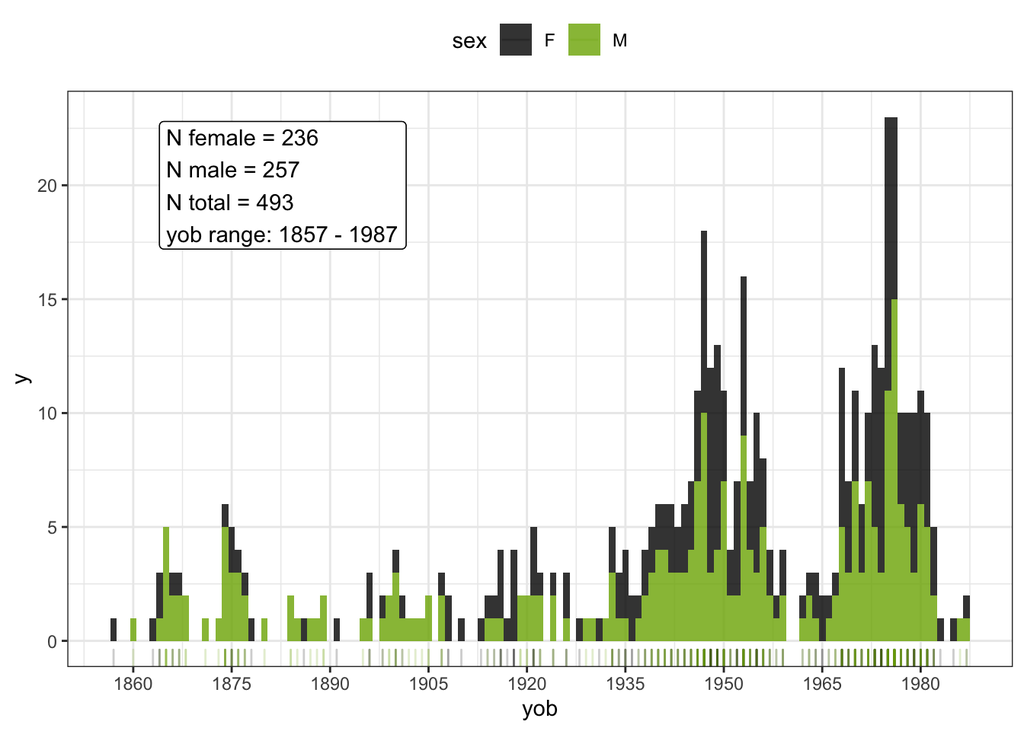

```r
#plot the distribution of speakers by year of birth and gender
left_join(price_speakers, mouth_speakers) %>%
  ggplot(aes(x = yob, fill = sex, colour = sex)) +
  geom_histogram(binwidth=1,
                 alpha = 0.8, colour = NA) +
  geom_rug(alpha = 0.2) +
  scale_x_continuous(breaks = seq(1860, 1990, 15)) +
  scale_fill_manual(values = c("black", "#7CAE00")) +
  scale_color_manual(values = c("black", "#7CAE00")) +
  geom_label(data = . %>% group_by(sex) %>% summarise(n = n()), aes(x = 1864, y = 20, label = paste0("N female = ", n[1], "\nN male = ", n[2], "\nN total = ", sum(n), "\nyob range: ", min(price_speakers$yob), " - ", max(price_speakers$yob))), hjust=0, inherit.aes = FALSE) +
  theme_bw() +
  theme(legend.position = "top")
```

```r
#get speaker and token n by generation
setdiff(names(price6), names(mouth6))
```

```
## character(0)
```

```r
setdiff(names(mouth6), names(price6))
```

```
## character(0)
```

```r
price_mouth <- rbind(price6 %>% mutate(vowel = "PRICE"),
                     mouth6 %>% mutate(vowel = "MOUTH"))

price_mouth %>%
  group_by(vowel, speaker) %>%
  mutate(n_tokens1 = n_distinct(id)) %>%
  ungroup() %>%
  select(vowel, generation, speaker, id, n_tokens1) %>%
  distinct() %>%
  group_by(vowel, generation) %>%
  summarise(n_speakers = n_distinct(speaker),
            n_tokens = n_distinct(id),
            mean_n_tokens = mean(n_tokens1))
```

| vowel | generation | n_speakers | n_tokens | mean_n_tokens |
| --- | --- | --- | --- | --- |
| MOUTH | 1857-1880 | 41 | 4353 | 150.71422 |
| MOUTH | 1881-1900 | 21 | 2231 | 136.07306 |
| MOUTH | 1901-1920 | 31 | 3857 | 153.63573 |
| MOUTH | 1921-1940 | 50 | 4081 | 218.64420 |
| MOUTH | 1941-1960 | 157 | 6164 | 54.52271 |
| MOUTH | 1961-1980 | 173 | 6735 | 62.20327 |
| MOUTH | 1980+ | 20 | 520 | 30.84615 |
| PRICE | 1857-1880 | 41 | 4249 | 160.09108 |
| PRICE | 1881-1900 | 21 | 2553 | 150.94516 |
| PRICE | 1901-1920 | 31 | 4492 | 190.91941 |

[output cut: 4 more lines]

```r
saveRDS(price_mouth, "final_data/price_mouth_final.rds")

#see who the speakers are with the most/least tokens
#this explains why 1921-1940 has a high mean token count, with one speaker having over 3 times more PRICE tokens than the next highest speaker
price_mouth %>%
  select(vowel, generation, speaker, id) %>%
  distinct() %>%
  group_by(vowel, speaker, generation) %>%
  summarise(n_tokens = n_distinct(id)) %>%
  arrange(-n_tokens) %>%
  head(10)
```

| vowel | speaker | generation | n_tokens |
| --- | --- | --- | --- |
| PRICE | Jack Reid | 1921-1940 | 1022 |
| MOUTH | Jack Reid | 1921-1940 | 698 |
| PRICE | Marjorie Stewart | 1901-1920 | 336 |
| PRICE | Frank Shepherd | 1857-1880 | 321 |
| PRICE | Chris Dixon | 1857-1880 | 306 |
| PRICE | fyn95-13 | 1961-1980 | 297 |
| PRICE | Runa Williams | 1901-1920 | 283 |
| PRICE | John Martin | 1881-1900 | 272 |
| PRICE | Dennis Kemp | 1921-1940 | 267 |
| MOUTH | Frank Shepherd | 1857-1880 | 264 |

```r
#might consider removing the speaker with 3 tokens
price_mouth %>%
  select(vowel, generation, speaker, id) %>%
  distinct() %>%
  group_by(vowel, speaker, generation) %>%
  summarise(n_tokens = n_distinct(id)) %>%
  arrange(n_tokens) %>%
  head(10)
```

| vowel | speaker | generation | n_tokens |
| --- | --- | --- | --- |
| MOUTH | fyp96-24 | 1961-1980 | 3 |
| MOUTH | fop01-1a | 1961-1980 | 5 |
| MOUTH | fop99-26 | 1941-1960 | 5 |
| MOUTH | fon06-3 | 1941-1960 | 6 |
| MOUTH | fyn96-1b | 1961-1980 | 7 |
| PRICE | fyn06-5 | 1961-1980 | 7 |
| MOUTH | fop96-10a | 1941-1960 | 8 |
| MOUTH | fyn06-5 | 1961-1980 | 8 |
| MOUTH | fyp99-8a | 1961-1980 | 8 |
| MOUTH | mop96-25a | 1941-1960 | 9 |

```r
#data for shiny app so we can compare tokens that have been filtered out to those that were kept
price_mouth_raw <- rbind(price %>% mutate(vowel = "PRICE"),
                     mouth %>% mutate(vowel = "MOUTH"))

price_mouth1 <- price_mouth %>%
  select(speaker, yob, generation, sex, id, measurement_no, f1, f2, f3, vowel)

price_mouth_raw1 <- price_mouth_raw %>%
  select(speaker, yob, generation, sex, id, measurement_no, f1, f2, f3, vowel)

price_mouth1_filtered <- setdiff(price_mouth_raw1, price_mouth1) %>%
  mutate(filtered = "raw")

price_mouth_all <- rbind(price_mouth1 %>%
                           mutate(filtered = "final"), price_mouth1_filtered)

saveRDS(price_mouth_all, "final_data/price_mouth_raw.rds")
```

```r
#set end time
cat(paste0("End time:\n", format(Sys.time(), "%d %B %Y, %r")))
```

```
## End time:
## 08 November 2021, 05:20:01 pm
```

```r
end_time <- Sys.time()

cat(paste0("\n---------------\nTotal time to compile:\n", as.numeric(end_time - start_time), " minutes\n---------------\n"))
```

```
##
## ---------------
## Total time to compile:
## 7.92949105103811 minutes
## ---------------
```